# Chap2_Workflow_Basic

DeukJung

2020 9 29

# **2장 워크플로: 기초**

## **2.1 코딩 기초**

### 1. 계산기 기능

```r
1 / 200 * 30
```

```
## [1] 0.15
```

```r
(59 + 73 + 2) / 3
```

```
## [1] 44.66667
```

```r
sin(pi / 2)
```

```
## [1] 1
```

### 2. 객체 생성 기능

- **<-** 를 사용

```r
x <- 3*4
```

- " = " 기호 사용하지 말 것
- " <- " 기호를 사용할 것 **(단축키: Alt + -)**
- 코드를 볼 때 혼잡함을 방지하기 위해 공백을 꼭 사용하자!

## **2.2 이름에 들어갈 것**

1. 객체의 이름은 문자로 시작
2. 문자, 숫자, _, . 만을 포함해야 함
3. 여러 단어를 이어쓸 경우, 띄어쓰기 보다는 " _ "로 구분하는 snake_case를 사용하여 구분할 것

```r
i_use_snake_case
otherPeopleUseCamelCase
some.people.use.periods
And_aFew.People_RENOUNCEconvention
```

4. 객체를 확인하려면 이름을 타이핑하자.

```r
x
```

```
## [1] 12
```

5. Rstudio 완성기능

```r
this_is_a_really_long_name <- 2.5
```

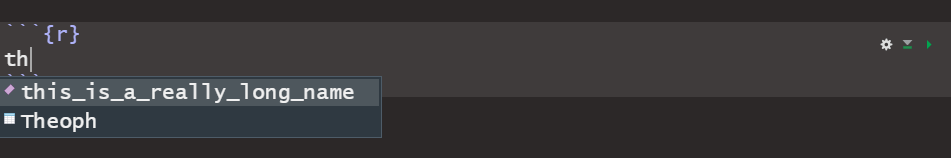

RStudio완성기능

6. 명령어를 수정해야할 경우, Cmd/Ctrl + ↑ 를 사용하면 명령어 중 그 문자로 시작 하는 것들을 보여준다.
7. 명령어를 정확히 입력하자

```r
r_rocks <- 2 ^ 3
```

```r
r_rock
```

```
#> Error: object 'r_rock' not found
```

```r
R_rocks
```

```
#> Error: object 'R_rocks' not found
```

철자, 대문자, 소문자 등 정확히 입력하도록 한다.

## **2.3 함수 호출하기**

- R은 다음과 같이 호출되는 내장 함수가 많이 있다.

```r
function_name(arg1 = val1, arg2 = val2, ...)
```

- 숫자 시퀀스 seq()를 이용해보자.

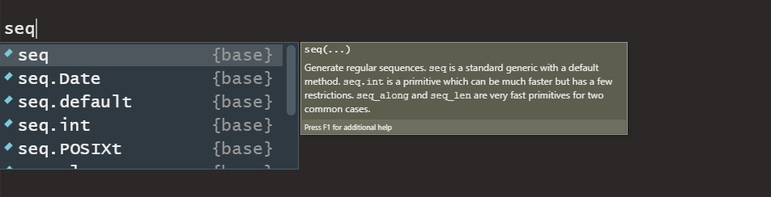

  - 팝업되는 툴팁은 해당함수의 인수와 목적을 알려준다.
  - 도움이 더 필요하면 F1 키를 눌러서 하단 오른쪽 창의 Help 탭에 있는 세부내용을 참고하자.
- 화살표로 원하는 함수를 선택했을 때 Tab을 누르면 여는 괄호( 와 닫는 괄호) 한 쌍이 생성된다.

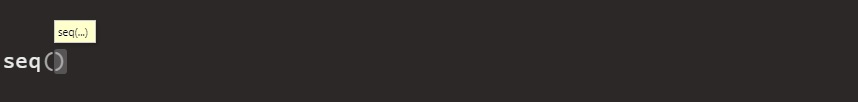

- 1, 10을 타이핑 하고 실행해보자.

```r
seq(1, 10)
```

```
##  [1]  1  2  3  4  5  6  7  8  9 10
```

- 따옴표를 활용하여 다음의 코드를 타이핑해보자.

```r
x <- "hello world"
```

```
- 따옴표와 괄호는 항상 짝을 이루어야 한다.
```

```r
> x <- "hello
+
```

```
- " 또는 )를 누락한 경우, 입력이 완료되자 않았다고 인식되어 +표시가 뜬다.
```

- 할당문을 완성했다고 값을 바로 볼 수는 없다. 명령어를 입력해야 값을 볼 수 있다.

```r
y <- seq(1, 10, length.out = 5)
y
```

```
## [1]  1.00  3.25  5.50  7.75 10.00
```

- 결과를 즉시 확인하고 싶을 경우, 할당문을 괄호로 묶으면 할당이 되고 바로 스크린에 인쇄된다.

```r
(y <- seq(1, 10, length.out = 5))
```

```
## [1]  1.00  3.25  5.50  7.75 10.00
```

- 상단 오른쪽 창의 Enviroment에서 생성한 객체를 모두 볼 수 있다.

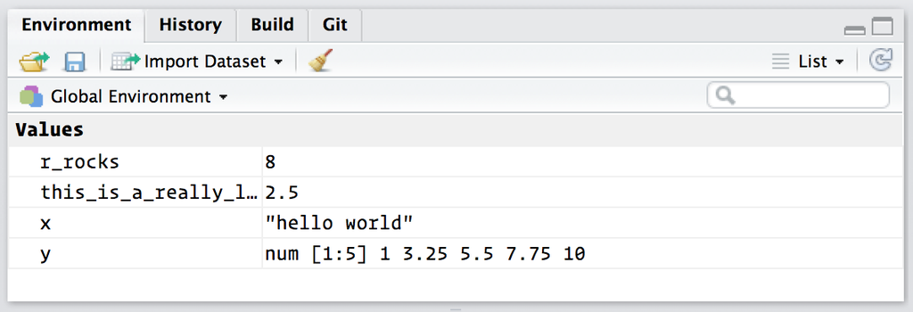